# Landscapes, limits, and the first two positions

TC6035 · Advanced Algorithms and Bioinspired Techniques · Session 1 of 4

Prof. Víctor Adrián Sosa Hernández

Tecnológico de Monterrey — Doctoral Programme

## Where this session sits

Four sessions, and they are one argument rather than four topics.

| **S1** | trajectory begins | landscapes · Monte Carlo · annealing |
| --- | --- | --- |
| S2 | memory becomes explicit | tabu search · PSO core |
| S3 | memory becomes social | PSO topologies · stability · ACO core |
| S4 | memory leaves the searcher | MMAS · comparative study |

## The spine

```
trajectory  →  population  →  construction
```

And underneath it, one question: **where does the memory live?**

| Monte Carlo | nowhere |
| --- | --- |
| Simulated annealing | nowhere — but a temperature-driven bias |
| Tabu search | in the searcher, explicit and short |
| PSO | in the searcher *and* in the swarm |
| ACO | in the **environment** — stigmergy |

# 1 · What makes a problem hard

## Optimization, stated once

$$\max_{\mathbf{x}\,\in\,\Omega} f(\mathbf{x}) \qquad \text{s.t.} \qquad \mathbf{g}(\mathbf{x}) \le \mathbf{0}$$

$\mathbf{x}$ is a **vector** of $n$ decision variables, not a number. $\Omega \subseteq \mathbb{R}^{n}$ is the search space, and $\mathbf{g}: \Omega \to \mathbb{R}^{m}$ collects the $m$ constraints.

**The structure of $\Omega$ is the first classification, and it decides everything downstream:**

|  | $\Omega$ |  |
| --- | --- | --- |
| continuous | $\Omega \subseteq \mathbb{R}^{n}$ | gradient-like reasoning available |
| combinatorial | $\Omega \subseteq \mathbb{Z}^{n}$, or a finite set | neighbourhood must be defined, not assumed |
| **mixed** | $\Omega = \Omega_d \times \Omega_c \subseteq \mathbb{Z}^{n_d} \times \mathbb{R}^{n_c}$ | **both, and they interact** |

## Your problem is the third row

$$\mathbf{x} = (\mathbf{z}, \mathbf{p}), \qquad
\mathbf{z} \in \{0,1\}^{80}, \qquad
p_i \in [p_{\min},\, c_i]$$

$\mathbf{z}$ selects which of 80 candidate sites are active — **discrete**. $\mathbf{p}$ assigns transmit power to each — **continuous**, and bounded by that site’s *own* cap $c_i$.

**$n = 160$** decision variables: 80 binary and 80 real. And $\Omega_d$ and $\Omega_c$ are not independent — the feasible powers depend on which sites are active, and the worthwhile sites depend on the powers they can sustain.

M0 asks you to write this formulation yourself, for *your* instance, and to demonstrate the interaction rather than assert it.

## What makes one hard

Beyond the structure of $\Omega$:

- **modality** — one basin or many
- **ruggedness** — how much a neighbour tells you about a point
- **deception** — whether local structure points *away* from the optimum
- **separability** — whether variables can be optimized one at a time
- **constraint geometry** — is the feasible region even easy to reach?

Separability is the one most underestimated. A separable problem in $n$ dimensions is $n$ problems in one dimension. **Yours is not separable** — that is what the coupling between $\Omega_d$ and $\Omega_c$ means.

## Ruggedness is measurable, not a vibe

Random-walk autocorrelation: walk the neighbourhood accepting *every* move — improving or not — record $f$ along the way, and take the lag-1 correlation.

$$\rho_1 = \operatorname{corr}\!\big(f(\mathbf{x}_t),\, f(\mathbf{x}_{t+1})\big)$$

| $\mathbf{x}_t$ | the solution visited at step $t$ of the walk |
| --- | --- |
| $\mathbf{x}_{t+1}$ | its neighbour, reached by one move |
| $\rho_1$ | correlation between consecutive objective values, over the whole walk |

Accepting every move matters: the walk must sample the neighbourhood, not climb it.

| $\rho_1$ | reading | consequence |
| --- | --- | --- |
| $\to 1$ | neighbours are informative | local search is justified |
| $\approx 0$ | neighbourhood is noise | local search has nothing to exploit |

You will compute this on your own instance in **M0 Question 4**. It is the evidence that justifies — or refuses — every local method you use afterwards.

## Complexity, in the right units

**The wrong answer**

$O(T \cdot N \cdot d)$

Counts bookkeeping. Not comparable across algorithms that do different amounts of non-objective work per solution.

**The right answer**

**Function evaluations.**

In real applications the objective dominates everything else by orders of magnitude.

Your assignment budget is **5 000 evaluations, enforced**. The 5 001st call raises. A batch of $n$ costs $n$.

Fixing the budget is what makes the comparison fair: it equalizes the resource that actually costs, so the comparison is about search quality per evaluation rather than implementation efficiency.

# 2 · No Free Lunch

## The theorem, stated carefully

> Averaged over **all** objective functions, all search algorithms have identical performance.

The precondition that is almost always dropped:

That set of *all* functions is **closed under permutation** of its codomain. For every function where your algorithm excels, the set contains another — equally a member — where it fails by exactly as much.

Real problem classes are a vanishingly small, highly structured subset that is **not** closed under permutation. The averaging argument does not reach them.

## What NFL forbids, and what it does not

| ✗ “no algorithm is better than another” | **false** as stated |
| --- | --- |
| ✗ “comparing algorithms is pointless” | **backwards** |
| ✓ “no algorithm is superior across *all* conceivable functions” | correct |
| ✓ “algorithm choice must be justified *with respect to problem structure*” | the actual lesson |

NFL is an argument **for** empirical comparison on a specified class — and for stating which class your result holds for.

# 3 · Monte Carlo

## The position with no memory and no bias

Sample uniformly. Keep the best. That is the whole algorithm.

```python
best = -inf
while budget_remains:
    x = sample_uniform(X)
    best = max(best, f(x))
```

Why it earns a place in a doctoral course:

- it is the **honest baseline** — anything that cannot beat it is not exploiting structure
- its convergence is characterizable, and slow: $P(\text{miss}) = (1-p)^n$
- it is **unbiased**, which no other algorithm here can claim

## Where the budget goes

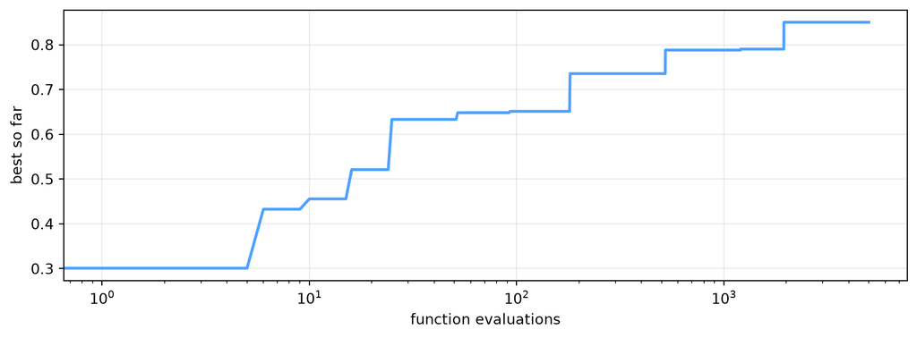

Best-so-far under uniform sampling: the curve flattens because each draw is independent of every previous one.

```python
import numpy as np
import matplotlib.pyplot as plt

rng = np.random.default_rng(7)
draws = rng.beta(2.5, 6.0, size=5000)          # stand-in for objective values
best = np.maximum.accumulate(draws)

fig, ax = plt.subplots(figsize=(9, 3.4))
ax.plot(best, lw=2, color="#4ea1ff")
ax.set_xlabel("function evaluations"); ax.set_ylabel("best so far")
ax.set_xscale("log"); ax.grid(alpha=.25)
fig.tight_layout()
```

# 4 · Simulated annealing

## One point, one temperature

From the current solution $\mathbf{x}$, propose a neighbour $\mathbf{x}'$. If it is worse, accept it anyway with probability

$$P(\text{accept}) = \exp\!\left(\frac{\Delta f}{T}\right)$$

| $\Delta f$ | $f(\mathbf{x}') - f(\mathbf{x})$ | how much worse the proposal is |
| --- | --- | --- |
| $T$ | current temperature, $T > 0$ | how tolerant the search is right now |
| $P$ | acceptance probability | $\in (0, 1)$ whenever $\Delta f < 0$ |

**We maximize, so $\Delta f < 0$ means worse.** Most of the literature minimizes and writes $\exp(-\Delta f / T)$ with $\Delta f > 0$ for a worsening move. Same rule, flipped sign — and getting it backwards accepts improvements probabilistically and worsenings always, which still *runs*.

**High $T$** — $\Delta f / T \to 0$, so $P \to 1$. Nearly everything accepted; the search wanders and can leave a basin.

**Low $T$** — $\Delta f / T \to -\infty$, so $P \to 0$. Only improvements survive: annealing *degenerates into hill climbing*.

There is still **no memory**. The temperature is a time-dependent bias, not a record of where the search has been. That distinction is the whole reason tabu search exists — next session.

## The guarantee, and why it is useless

Annealing converges in probability to the global optimum — **under a logarithmic schedule**:

$$T(k) = \frac{c}{\log k}$$

| $k$ | iteration number, $k \ge 2$ |
| --- | --- |
| $c$ | a constant that must be **at least the depth of the deepest local optimum** — which you do not know, because knowing it would mean having solved the problem |

$\log k$ grows so slowly that reaching a useful temperature takes a number of steps that, on any realistic instance, exceeds exhaustive enumeration. The guarantee is **asymptotic and operationally vacuous** at a fixed budget.

Everyone uses a **geometric** schedule instead:

$$T_{k+1} = \alpha\,T_k, \qquad 0 < \alpha < 1$$

$\alpha$ is the cooling factor — closer to 1 cools slowly. This abandons the guarantee deliberately, in exchange for behaving well within budget.

**Say that you abandoned it.** Citing the convergence proof to justify a geometric schedule invokes a theorem whose precondition your own code violates.

## Justify a schedule with numbers

Not “I used $\alpha = 0.999$ because it is standard”. Measure:

| acceptance rate of worsening moves, **first 10%** of budget | should be high |
| --- | --- |
| acceptance rate of worsening moves, **last 10%** of budget | should be near zero |

On the reference implementation for this problem: **0.894 → 0.013**, two orders of magnitude within 5 000 evaluations.

A schedule asserted without those two numbers is not justified.

## Next session

Tabu search — the moment memory becomes **explicit**.

And the first population: particle swarm optimization.

```
trajectory  →  population  →  construction
     ▲
   we are here
```